# Udacity - Data Analyst Nano Degree Project 4: Exploring Red Wine Quality with R

*After removing outliers:* R^2 = 0.3786

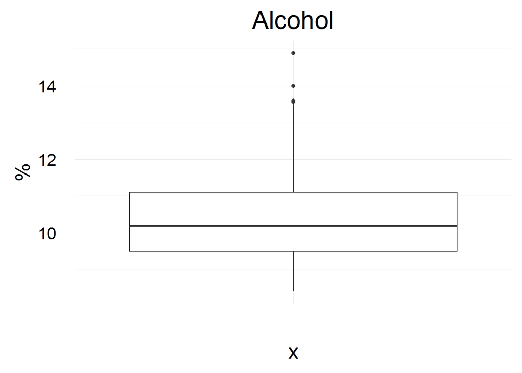

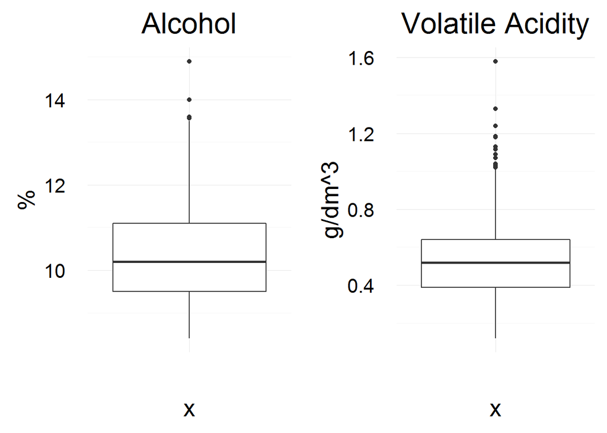

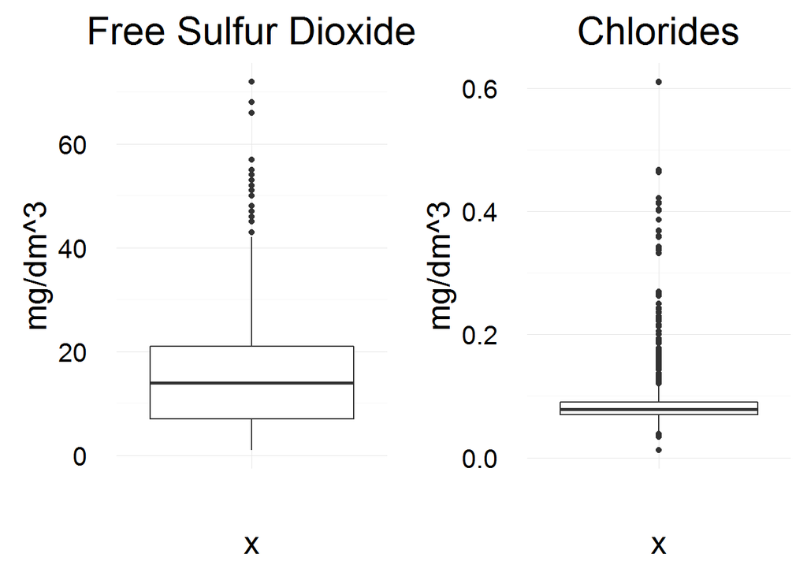

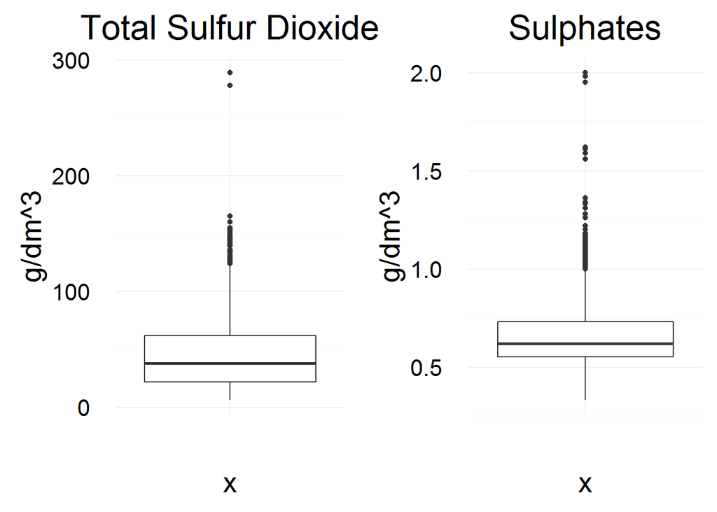

In order to give us an idea of how this model actually functions, beyond the statistical analysis, I chose one random red wine from each quality bin and put our model up to the test of predicting it’s quality. The output below shows the actual quality, followed by what the model predicted “fit” and the upper and lower boundaries at 95% confidence. Moving the 95% confidence value to 99% or 99.9% would further spread the boundaries away from the mean, or fitted value. The far left number is the row number that the wine is associated with.

```
##   quality
## 5       3
```

```
##        fit      lwr      upr
## 5 5.189716 3.942316 6.437116
```

```
##    quality
## 40       4
```

```
##         fit      lwr      upr
## 40 5.634095 4.388711 6.879479
```

```
##     quality
## 161       5
```

```
##          fit      lwr      upr
## 161 5.543966 4.297525 6.790408
```

```
##     quality
## 768       6
```

```
##          fit     lwr      upr
## 768 5.528469 4.28318 6.773759
```

```
##      quality
## 1424       7
```

```
##           fit      lwr      upr
## 1424 6.431082 5.184094 7.678069
```

```
##      quality
## 1580       8
```

```
##           fit      lwr      upr
## 1580 6.226167 4.590015 7.862318
```

We can see from these results that the model does an decent job of giving a ballpark estimate for the quality of the red wine.

## Final Plots and Summarry

### Plot One

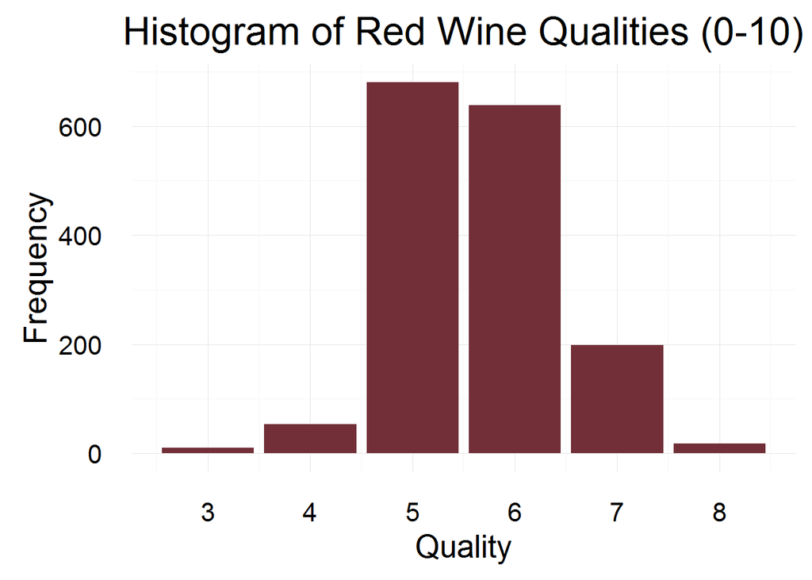

### Description One

The histogram above depicting red wine quality is heavily centered around the 5 and 6 quality rankings. With approximately 80% of the observations being 5’s and 6’s a normalized distribution, which is desired, is not given to us in this data set. This will cause our predictive models to be less accurate for wine qualities in the 3-4 area and the 7-8 area.

### Plot Two

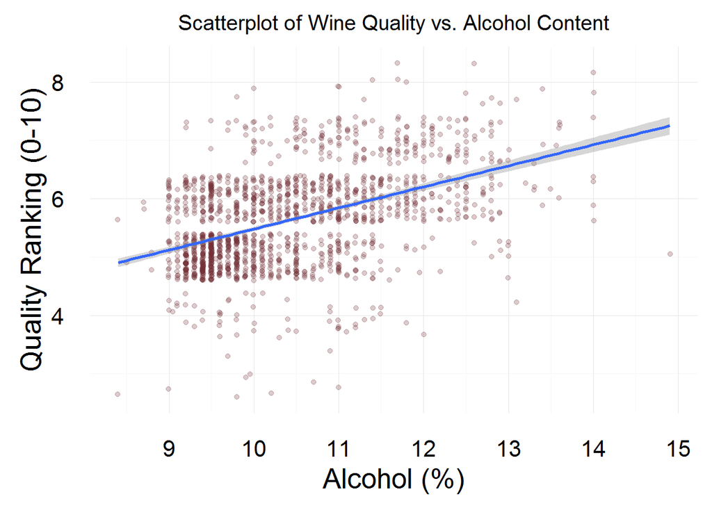

### Description Two

The scatter plot of wine quality vs alcohol content shows the predictor variable that has the highest statistical significance of all variables in the data set. Intuitively, it doesn’t really make sense that by adding additional alcohol would increase the quality of wine, but in the case of this data set it seems that wines of the higher alcohol content tend to have properties of a higher quality wine. Something else that can be taken from this graph is that we are able to observe a heavy grouping of rank 5 wines that have alcohol content between 9 and 10 percent.

### Plot Three

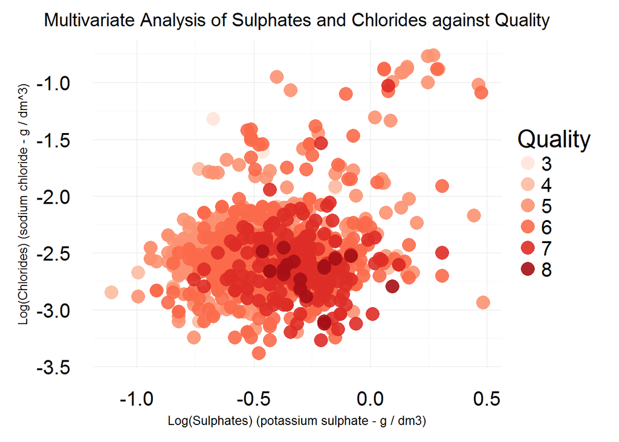

## Reflection

The Red Wine data set contains information on almost 1,600 bottles of red wine across 12 different variables, 11 predictor variables and 1 output variable (Quality). I started this investigation by looking at the distribution of each of the predictor variables via a histogram, as well as looking at the direct correlation between each individual variable and quality. From this point I used the knowledge of the distributions along with the correlations each variable had with the output variable to determine if any variable transformations should be made i.e. the square root and the log base 10 transformations.

There were clear trends between a few of the variables such as alcohol and quality that were obvious right away. Next I began to look into how the predicting variables interacted with each other via a matrix. It was difficult to tell from this output alone what kind of variables might have interaction which would further improve the model I was about to make. It seemed, after further reading, that the best way to determine interaction is my modeling each pair of variables one by one and looking at the corresponding p-value. This seemed cumbersome and outside of the scope of this document and so I chose a couple pairs and brought them into my model analysis.

It would likely be the case that with a larger data set and further analysis on the interaction between variables we could create an even stronger model for predicting red wine quality. As well, we could additionally look for correlation between variables and remove variables that seemed to be highly correlated with each other as they may be providing the same information multiple times. There may also may be additional transformations that could have been done to the variables individually as well different ways to combine the variables.